# Data together and first quality control

Last compiled on 21 July, 2022

# Data together

## Load libraries

```r
library(Seurat)
library(plyr)
library(ggplot2)
library(DropletUtils)
library(celda)
library(SingleCellExperiment)
library(scater)
library(scran)
library(scDblFinder)
library(viridis)
library(MASS)
library(patchwork)
```

## Load extra sources

```r
get_density <- function(x, y, ...) { # function from https://slowkow.com/notes/ggplot2-color-by-density/
  dens <- MASS::kde2d(x, y, ...)
  ix <- findInterval(x, dens$x)
  iy <- findInterval(y, dens$y)
  ii <- cbind(ix, iy)
  return(dens$z[ii])
}

fancy_scientific <- function(l) { # function from https://stackoverflow.com/a/24241954
     # turn in to character string in scientific notation
     l <- format(l, scientific = TRUE)
     # quote the part before the exponent to keep all the digits
     l <- gsub("^(.*)e", "'\\1'e", l)
     # turn the 'e+' into plotmath format
     l <- gsub("e", "%*%10^", l)
     # return this as an expression
     parse(text=l)
}

setwd("~/000_GitHub/ibd-bcn_single_cell")
source('source/functions_scrnaseq.R')
source('source/colors.R')
```

## Sample Metadata

Metadata of the samples inside the code.

```r
metadata <- data.frame(
  stringsAsFactors = FALSE,
  sample = c("SC_002",
             "SC_004","SC_005","SC_008","SC_010","SC_011",
             "SC_013","SC_014","SC_015","SC_016","SC_017",
             "SC_018","SC_019","SC_021","TOF001W0","TOF002W0",
             "TOF005W0","TOF010W0"),
  sample_name = factor(c("HC 1", "CD 1", "CD 2", "UC 1", "UC 2", "HC 2",
                         "CD 3", "CD 4", "HC 3", "HC 4", "HC 5", "HC 6",
                         "CD 5", "CD 6", "UC 3", "UC 4", "UC 5", "UC 6"),
                       levels = c("HC 1", "HC 2", "HC 3", "HC 4",
                                  "HC 5", "HC 6", "CD 1", "CD 2",
                                  "CD 3", "CD 4", "CD 5", "CD 6",
                                  "UC 1", "UC 2", "UC 3", "UC 4",
                                  "UC 5", "UC 6")),
  Health = factor(c("HC", "CDa", "CDa","UCa","UCa","HC","CDa","CDa",
                    "HC","HC","HC","HC","CDa","CDa","UCa","UCa","UCa",
                    "UCa"), levels = c("HC", "CDa", "UCa")),
  Health_2 = factor(c("HC","IBD",
                      "IBD","IBD","IBD","HC","IBD","IBD","HC","HC",
                      "HC","HC","IBD","IBD","IBD","IBD","IBD",
                      "IBD"), levels = c("HC", "IBD"))
)
```

## Merge data (Seurat)

This code consists of a loop joining the data. First loads the sample, adds the sample’s metadata `m4`, and calculates the doublets and MT%. Puts each sample in an empty list `list_data`, and after the loop, merges the samples of the list using Seurat’s function `merge` into the new `seudata` object.

```r
setwd('~/data_Albas/DATA/') # Dir where we have a folder per sample, with the 3 files from
# outs/filtered_feature_bc_matrix from cellranger output.

list_files <- list.files() # folder names
list_data <- list() # empty list

for(i in list_files){
  # read the files
  sce2 <- Read10X(i)

  # feature filtering
  keep_feature <- rowSums(sce2 > 0) > 0
  sce2 <- sce2[keep_feature, ]

  # doublet finding
  sce2 <- scDblFinder(sce2, verbose=FALSE)

  # metadata of sample
  m4 <- data.frame('sample' = rep(i, ncol(sce2)),
                   'doublet' = sce2$scDblFinder.class,
                   'Health' = rep(metadata[metadata$sample == i, 'Health'][1], ncol(sce2)),
                   'sample_name' = rep(metadata[metadata$sample == i, 'sample_name'][1], ncol(sce2)),
                   'Health_2' = rep(metadata[metadata$sample == i, 'Health_2'][1], ncol(sce2)))

  # identify sample per colname
  colnames(sce2) <- paste(i, colnames(sce2), sep='_')
  rownames(m4) <- colnames(sce2)

  # seurat of the sample
  data <- CreateSeuratObject(
    counts(sce2),
    min.features = 100,
    project = i,
    assay = "RNA",
    meta.data = m4
  )

  # calcules the percent.mt per sample
  data[["percent.mt"]] <- PercentageFeatureSet(object = data, pattern = "^MT-")

  # add each sample into the empty list
  list_data[[i]] <- data
}

seudata <- list_data[[1]]
for(i in 2:length(list_files)){
  seudata <- merge(seudata, list_data[[i]])
}
```

# Data exploration and QC

## Violin Plots

Let’s check the MT% per cell and the number of genes per cell in each sample.

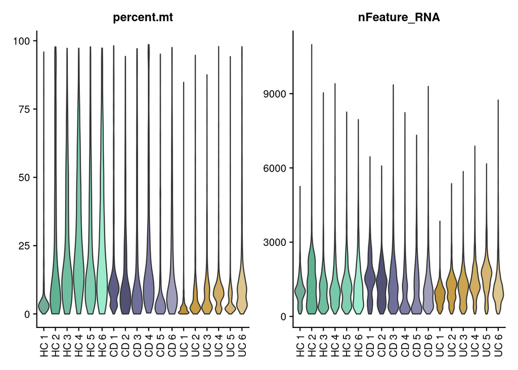

```r
VlnPlot(seudata, features = c('percent.mt', 'nFeature_RNA'),
        group.by = 'sample_name', pt.size = 0) &
  theme(text = element_text(family = 'Helvetica', size = 10),
        axis.text.x = element_text(angle = 90, vjust = 0.5,
                                   family = 'Helvetica', size = 10),
        axis.title.x = element_blank(),
        axis.text.y = element_text(family = 'Helvetica', size = 10)) &
  scale_fill_manual(values = c('#71ad96','#5fb392','#71bda0',
                               '#77c9a9','#82ceb1','#9debcc',
                               '#5d5c84','#525174','#6f6f9b',
                               '#7b7ba3','#8787ab','#9f9fbc',
                               '#bc9338','#c79d43','#cba552',
                               '#d0ad62','#d5b572','#dec691'))
```

## Scatter plot

Let’s check the distribution of the cells considering the total number of counts and the total number of genes per cell. First plot is colored by doublet. Second plot is colored by sample_name.

### Doublets

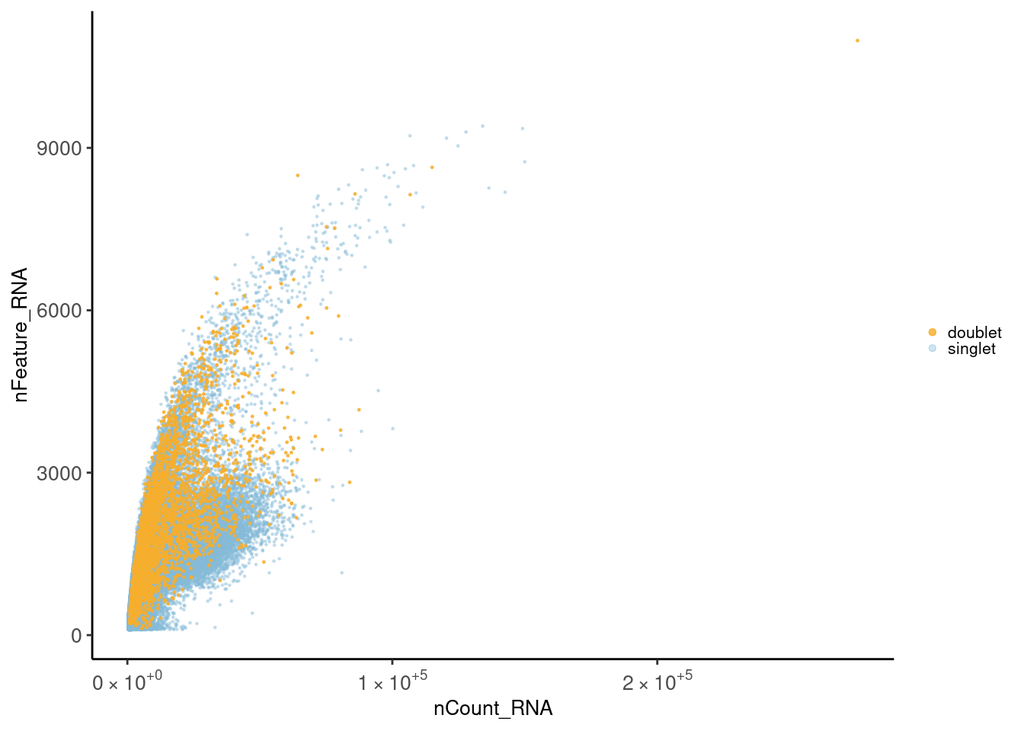

```r
meta <- seudata@meta.data
meta <- meta[order(meta$doublet, decreasing = T),]
ggplot(meta) +
  geom_point(aes(nCount_RNA, nFeature_RNA, color = doublet), size=0.2) +
  theme_classic() +
  scale_color_manual(values = c('doublet' = '#F6AE2DCC',
                                'singlet' = '#86BBD860'))+
  theme(plot.title = element_text(size = 25))+
  scale_x_continuous(labels=fancy_scientific) +
  theme(text = element_text(family = 'Helvetica', size = 10),
        axis.text.x = element_text(family = 'Helvetica', size = 10),
        axis.text.y = element_text(family = 'Helvetica', size = 10),
        legend.key.size = unit(5,"bigpts"), legend.title = element_blank())+
  guides(color = guide_legend(override.aes = list(size = 1.2)))
```

### Sample

```r
meta_dot <-  seudata@meta.data[sample(1:nrow(seudata@meta.data)), ]
sum(is.na(meta_dot$sample_name))
```

```
## [1] 0
```

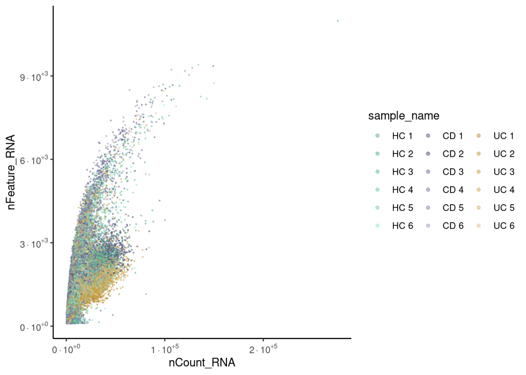

```r
ggplot(meta_dot) +
  geom_point(aes(x = nCount_RNA, y = nFeature_RNA, color = sample_name),
             size = 0.2) +
  theme_classic()+
  scale_x_continuous(labels=fancy_scientific) +
  scale_y_continuous(labels=fancy_scientific) +
  scale_color_manual(values = c('#71ad9680','#5fb39280','#71bda080',
                                '#77c9a980','#82ceb180','#9debcc80',
                                '#5d5c8480','#52517480','#6f6f9b80',
                                '#7b7ba380','#8787ab80','#9f9fbc80',
                                '#bc933880','#c79d4380','#cba55280',
                                '#d0ad6280','#d5b57280','#dec69180'))+
  guides(color = guide_legend(override.aes = list(size = 1.2), ncol=3))
```

## Filtering

We first filter out the cells that are considered doublets and let’s recheck the distribution of the cells after filtering.

### Number of cells/sample

Tables showing the number of cells classified as singlet and doublet. The table shows the global numbers. The barplot shows singlets/doublets per sample. In the code, we filter out the cells classified as doublet into a new object `seudataf`.

```r
ta <-  as.data.frame(table(seudata$doublet))
colnames(ta) <- c('category', 'n_cells')
knitr::kable(ta)
```

| category | n_cells |
| --- | --- |
| doublet | 3333 |
| singlet | 54221 |

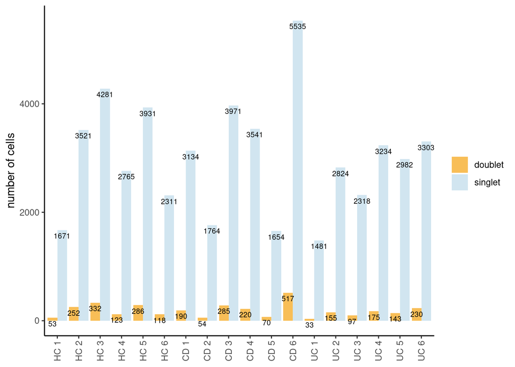

```r
ta2 <- as.data.frame(table(seudata$sample_name, seudata$doublet))
colnames(ta2) <- c('sample','doublet','n_cells')
ta2$sample <- factor(ta2$sample, levels = c("HC 1", "HC 2", "HC 3", "HC 4",
                                  "HC 5", "HC 6", "CD 1", "CD 2",
                                  "CD 3", "CD 4", "CD 5", "CD 6",
                                  "UC 1", "UC 2", "UC 3", "UC 4",
                                  "UC 5", "UC 6"))
ggplot(data=ta2, aes(x=sample, y=n_cells, fill=doublet)) +
  geom_bar(stat="identity", position=position_dodge())+
  geom_text(aes(label=n_cells), vjust=1.6, color="black",
            position = position_dodge(0.9), size=2.5)+
  scale_fill_manual(values = c('doublet' = '#F6AE2DCC',
                               'singlet' = '#86BBD860'))+
  labs(y = 'number of cells') +
  theme_classic()+
  theme(axis.text.x = element_text(angle=90, vjust=0.5),
        legend.title = element_blank(),
        axis.title.x= element_blank())
```

```r
seudataf <- seudata[,seudata$doublet == 'singlet']
```

### Distribution after doublet filtering

#### nCount/nFeatures

Distribution of cells in the scatter plot (ncount/nfeatures) without the doublets.

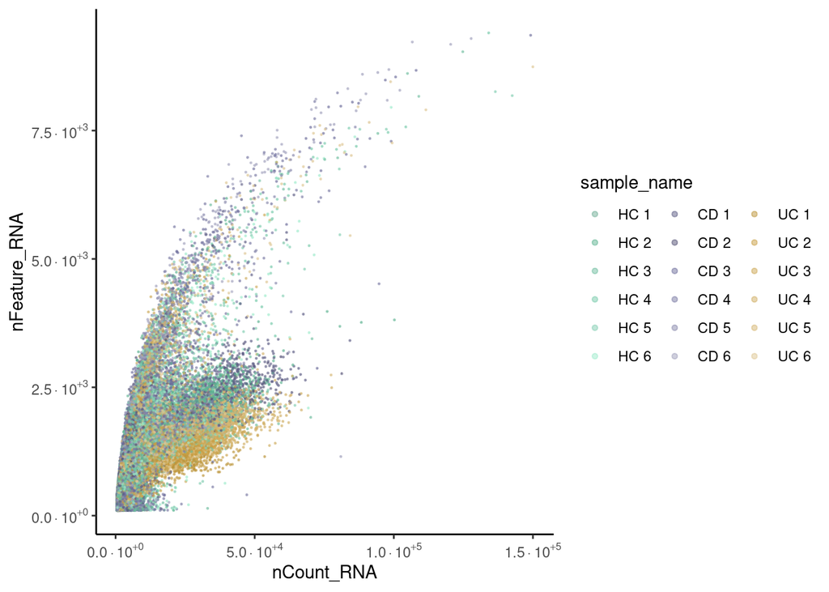

```r
meta_dot <-  seudataf@meta.data[sample(1:nrow(seudataf@meta.data)), ]
ggplot(meta_dot) +
  geom_point(aes(x = nCount_RNA, y = nFeature_RNA, color = sample_name),
             size = 0.2) +
  theme_classic()+
  scale_x_continuous(labels=fancy_scientific) +
  scale_y_continuous(labels=fancy_scientific) +
  scale_color_manual(values = c('#71ad9680','#5fb39280','#71bda080',
                                '#77c9a980','#82ceb180','#9debcc80',
                                '#5d5c8480','#52517480','#6f6f9b80',
                                '#7b7ba380','#8787ab80','#9f9fbc80',
                                '#bc933880','#c79d4380','#cba55280',
                                '#d0ad6280','#d5b57280','#dec69180'))+
  guides(color = guide_legend(override.aes = list(size = 1.2), ncol=3))
```

#### DERL3 expression

Plasma cells have more counts than other cells with the same number of features.

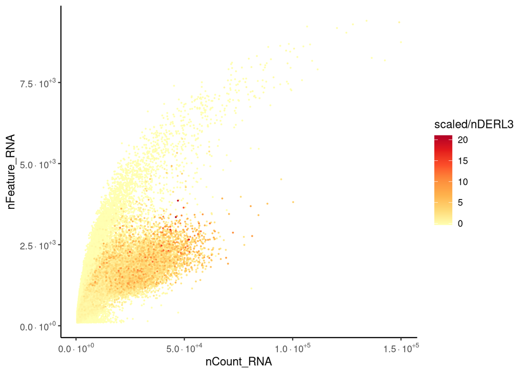

```r
seudataf2 <- seudataf
meta_dot2 <- FetchData(seudataf2, vars = c('nCount_RNA', 'nFeature_RNA', 'DERL3'))
meta_dot2$DERL3_scaled <- scale(meta_dot2$DERL3)[,1]
meta_dot2 <- meta_dot2[order(meta_dot2$DERL3_scaled),]
ggplot(meta_dot2) +
  geom_point(aes(x = nCount_RNA, y = nFeature_RNA, color = DERL3_scaled),
             size = 0.2) +
  theme_classic()+
  scale_color_distiller("scaled/nDERL3",
                        limits = c(min(meta_dot2$DERL3_scaled, na.rm = T),
                                   max(meta_dot2$DERL3_scaled, na.rm=T)),
                        na.value = "white", palette = "YlOrRd", direction = 1) +
  scale_x_continuous(labels=fancy_scientific) +
  scale_y_continuous(labels=fancy_scientific)
```

```r
rm(seudataf2, meta_dot2)
```

### MT% filtering after doublet filtering

Distribution of cells in scatter plot (nfeatures/percent.mt) to check where are the majority of our cells. We can see the dots colored by density using the function get_density shown in [Load extra functions and sources].

#### All cells

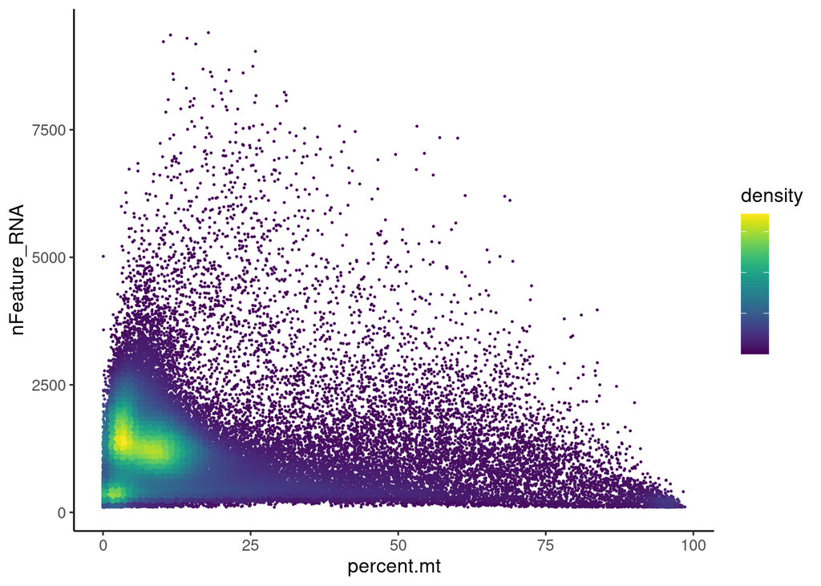

```r
meta <- seudataf@meta.data
meta$density <- get_density(meta$percent.mt, meta$nFeature_RNA, n = 100)
ggplot(meta) +
  geom_point(aes(percent.mt, nFeature_RNA, color = density), size = 0.2) +
  scale_color_viridis() + theme_classic() +
  theme(text = element_text( size = 12),
        axis.title = element_text( size = 12),
        legend.text = element_blank())
```

#### Cells >25% MT

Most cells are located between 0 and 25% MT. Nevertheless, let’s check the higher % of MT in more detail.

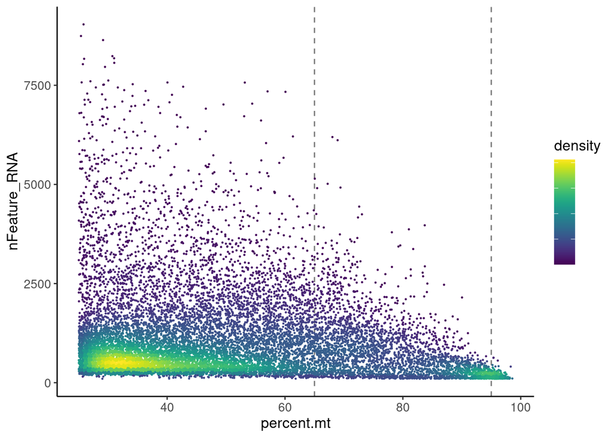

```r
meta2 <- seudata@meta.data[seudata@meta.data$percent.mt > 25,]
meta2$density <- get_density(meta2$percent.mt, meta2$nFeature_RNA, n = 100)

ggplot(meta2) +
  geom_vline(xintercept = 65, color = '#7A7A7A', linetype="dashed") +
  geom_vline(xintercept = 95, color = '#7A7A7A', linetype="dashed") +
  geom_point(aes(percent.mt, nFeature_RNA, color = density), size = 0.2) +
  scale_color_viridis() + theme_classic() +
  theme(plot.title = element_text(size = 25))+
  theme(text = element_text( size = 12),
        axis.text.x = element_text( size = 10),
        axis.text.y = element_text( size = 10),
        legend.text = element_blank())
```

There are two main densities in the plot, one between 25 and 65, and the second around 95%.  
We keep all cells <65%MT and get rid of the density around 95%, which will bring no information to the data set.

#### MT filtering

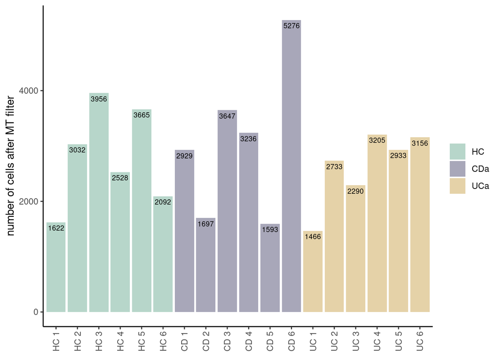

```r
seudataf <- seudataf[,seudataf$percent.mt < 65]
seudataf
## An object of class Seurat
## 28287 features across 51056 samples within 1 assay
## Active assay: RNA (28287 features, 0 variable features)

ta3 <- as.data.frame(table(seudataf$sample_name, seudataf$Health))
colnames(ta3) <- c('sample','Health','n_cells')
ta3 <- ta3[ta3$n_cells != 0,]
ta3$sample <- factor(ta3$sample, levels = c("HC 1", "HC 2", "HC 3", "HC 4",
                                  "HC 5", "HC 6", "CD 1", "CD 2",
                                  "CD 3", "CD 4", "CD 5", "CD 6",
                                  "UC 1", "UC 2", "UC 3", "UC 4",
                                  "UC 5", "UC 6"))
ggplot(data=ta3, aes(x=sample, y=n_cells, fill=Health)) +
  geom_bar(stat="identity", position=position_dodge())+
  geom_text(aes(label=n_cells), vjust=1.6, color="black",
            position = position_dodge(0.9), size=2.5)+
  scale_fill_manual(values = colors_health_alpha)+
  labs(y = 'number of cells after MT filter') +
  theme_classic()+
  theme(axis.text.x = element_text(angle=90, vjust=0.5),
        legend.title = element_blank(),
        axis.title.x= element_blank())
```

### Genes without expression filtering

```r
counts <- seudataf@assays$RNA@counts
pp <- which(Matrix::rowSums(counts)==0)
length(pp)
```

```
## [1] 278
```

```r
xx <-setdiff(rownames(seudataf), names(pp))
seudataf <- subset(seudataf, features = xx)
seudataf
## An object of class Seurat
## 28009 features across 51056 samples within 1 assay
## Active assay: RNA (28009 features, 0 variable features)
```

# Save data as RDS file

```r
setwd('~/000_GitHub/ibd-bcn_single_cell/')
saveRDS(seudataf, file = 'Analysis of our data/02_Samples_Together/filtered_data_together.RDS')
```